# Linear and Regression Model of Movies Data

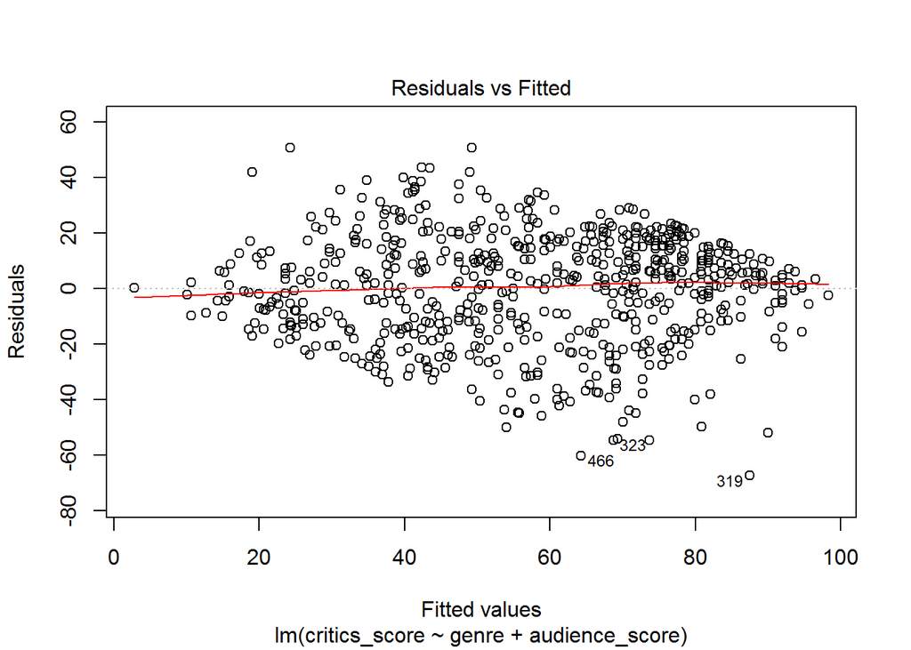

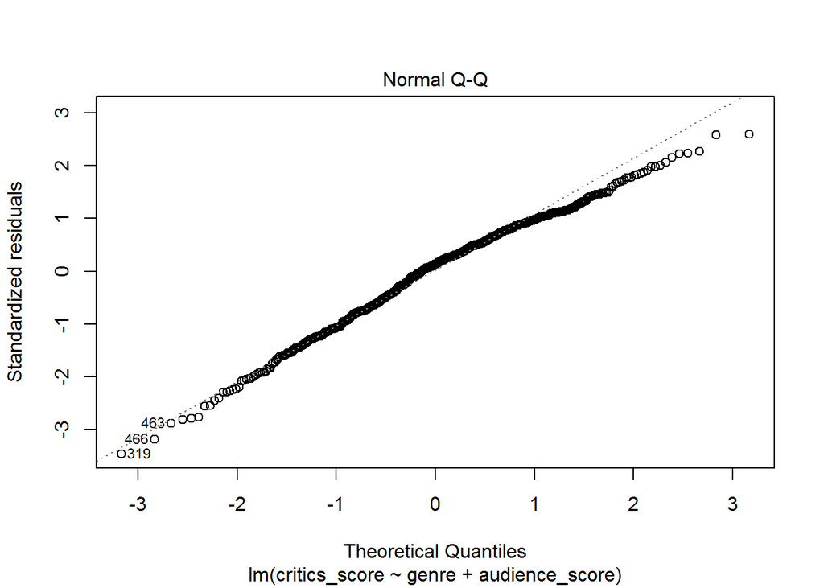

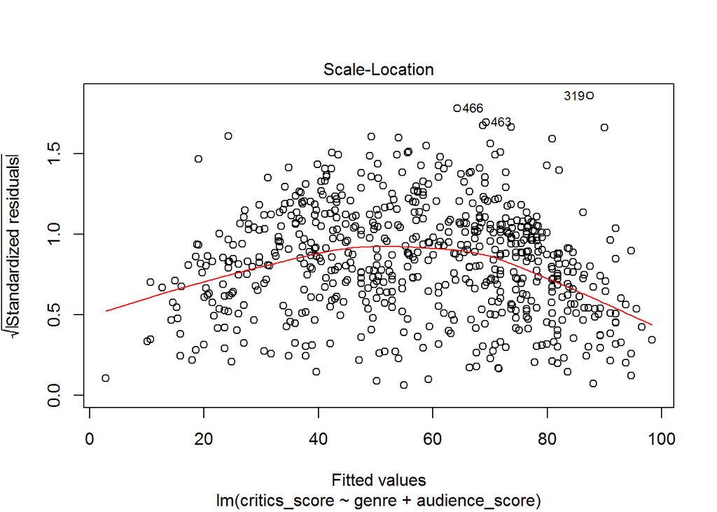

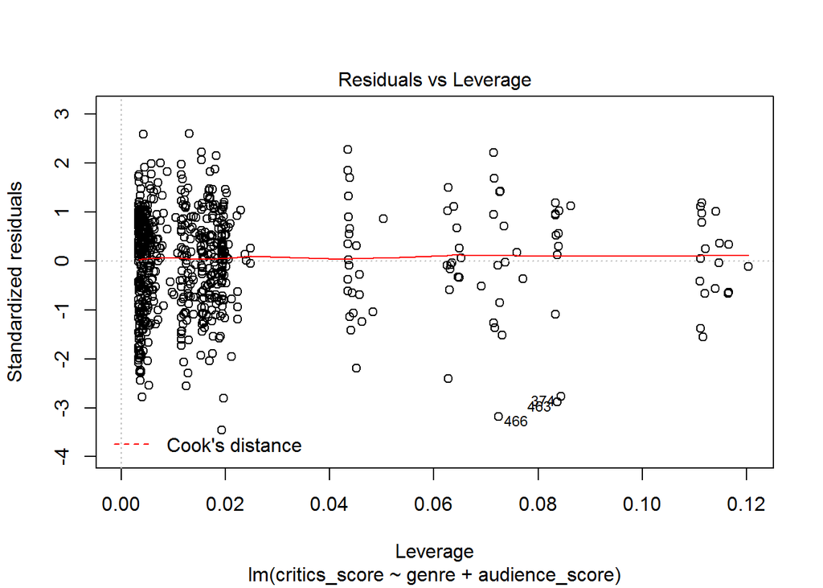

```r
plot(my_model_regre)
```

# Part 5. Prediction

I choose Dangal movie released in 2016 to predict my model and check it out it’s reviews,i.e. score from rotten tomatoes website. I collected the information about the movie from the website “https://www.rottentomatoes.com”

1. genre = Drama, 2. score of critics = 92 and 3. score of audience = 95 .

The interval taken is confidence.

```r
library(caret)
predict(my_model_regre, data.frame(genre="Drama",
critics_score = 92, audience_score =95), interval = "confidence")
```

```
##        fit      lwr      upr
## 1 89.00804 85.68761 92.32847
```

```r
confint(my_model_regre)
```

```
##                                      2.5 %     97.5 %
## (Intercept)                    -13.7268581 -0.5908677
## genreAnimation                 -12.7946849 14.7308151
## genreArt House & International -10.4342144 12.4010013
## genreComedy                     -5.6921642  6.9803944
## genreDocumentary                11.1623336 26.3331210
## genreDrama                       4.9761576 15.7094916
## genreHorror                      0.3167011 19.1144538
## genreMusical & Performing Arts  -0.9374381 23.7415437
## genreMystery & Suspense          4.5950490 18.4968845
## genreOther                       0.9496189 22.6256177
## genreScience Fiction & Fantasy  -2.5606082 24.9311341
## audience_score                   0.8199193  0.9869034
```

```r
par("mar")
```

```
## [1] 5.1 4.1 4.1 2.1
```

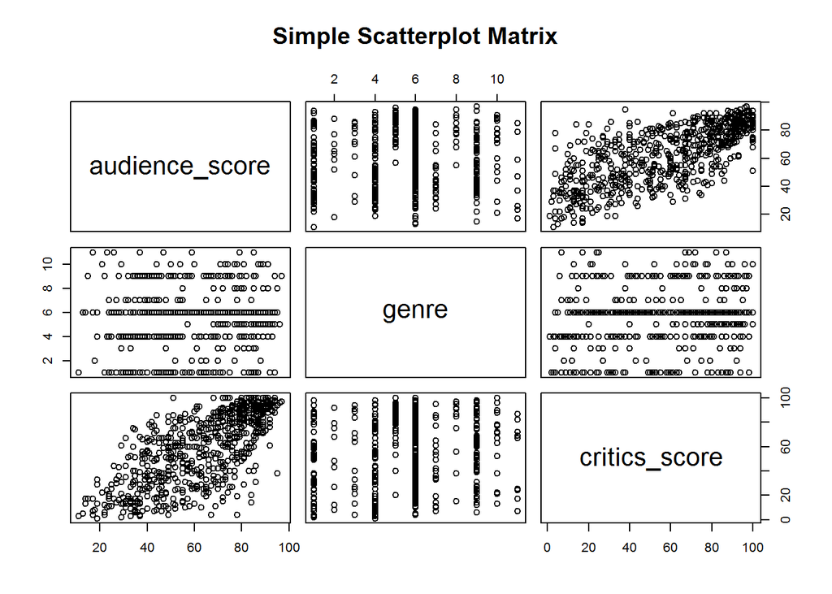

```r
par(mar=c(.2,.2,.2,.2))
pairs(~audience_score +genre +critics_score, data = movies,
main = "Simple Scatterplot Matrix")
```

# Part 6. Conclusion :

This project help me to understand the exploratory data analysis analysis, modeling and prediction and also made me understand the concept of the ratings of movies. According to the research question, I found that the most impact putting variables for getting the best movie review on rotten tomatoes website are the score of critics and the audience.

I found some shortcomings while in some research senerio for which I started reading more datasets and website data so I can understand and find out the researchable questions.

For the further research I recommend that we can also find that “if there is any impact on the moovie rating based on it’s release month because I realize that in some countrys outside India(my country) they have snowfall in particular months and they enjoy the outings in summers(most probably), so we can make a model which can predict this.”